# Analyzing WeRateDogs Data

> *Tarun Lingam*

## Introduction

WeRateDogs is a Twitter account that rates pictures of people's dogs with a humorous comment about the dog. These ratings almost always have a denominator of 10. The numerators, though? Almost always greater than 10. 11/10, 12/10, 13/10, etc. Why? Because "they're good dogs Brent."

It was started in 2015 by Matt Nelson, and has received international media coverage both for its popularity and for the attention drawn to social media copyright law when it was suspended by Twitter. As of October 2017, the Twitter account has close to four million followers and Nelson sees 30,000 likes on a post as being viral. His most popular post was of a dog marching in the 2017 Women's March, which was retweeted more than 50,000 times and favourited 134,000 times

```python
# Import the reqired packages
import pandas as pd
import numpy as np
import matplotlib.pyplot as plt
% matplotlib inline
```

```python
# Read the data into a dataframe
twitter = pd.read_csv('twitter_archive_master.csv')
```

## Dog Ratings

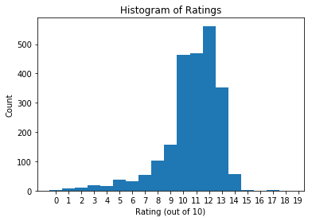

```python
# Plot the ratings that are less than 20
plt.hist(twitter.rating_numerator[twitter.rating_numerator <= 20],
         bins=np.arange(0,20,step=1), align='left');
plt.xticks(np.arange(0,20,step=1));
plt.title('Histogram of Ratings');
plt.xlabel('Rating (out of 10)');
plt.ylabel('Count');
```

- The most common ratings for dogs are 10/10, 11/10, 12/10, and 13/10, with the median rating being 11/10.
- An attribute of the rating system is the ability to rate multiple dogs at once.
  - Let’s say that you have a picture of two dogs, and you want to rate them as 12/10. Since there are two of them, the rating would actually be 24/20!
- With respect to the histogram of ratings, multi-dog ratings have already been normalized to be single-dog ratings.
- The vast majority of tweets were for a single dog.

### Highest Rated Dog

[figure not shown]

- The highest rated dog was Atticus on July 4, 2017. He dressed nicely with an American flag on the day of independence. He was rated with this comment "This is Atticus He's quite simply America af 1776/10".

### Most popular dog breeds

- You may ask, “What breed of dogs are most commonly rated?”
- In the data we looked at, there were hundreds of kinds of dogs, and the most common type of dog only accounted for 7.18% of tweets.
- The most popular dog breeds are
  - **Golden Retriever (with 7.18% of tweets)**

[figure not shown]

  - **Labrador Retriever (with 4.82% of tweets)**

[figure not shown]

  - **Pembroke Welsh Corgi (with 4.29% of tweets)** and

[figure not shown]

  - **Chihuahua (with 4.00% of tweets)**.

[figure not shown]

People do love their retrievers.

### Favorites and Retweets

- There was quite a range in number. Some tweets didn’t have any ‘favorites’ or ‘retweets’.
- One had a favorite count over 140,000, and another had a retweet count of close to 80,000.
- There was a fairly linear relationship between ‘favorite_count’ and ‘retweet_count’ for a particular tweet.

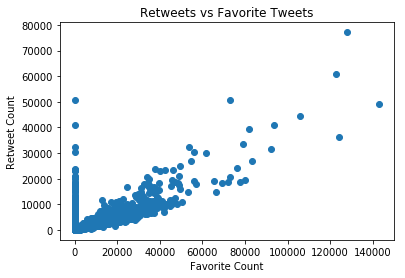

```python
# Plot retweet_count vs favorite_count
plt.scatter(twitter.fav_count, twitter.retweet_count)
plt.xlabel('Favorite Count')
plt.ylabel('Retweet Count')
plt.title('Retweets vs Favorite Tweets');
```

## Conclusion

WeRateDogs is an entertaining Twitter account, and if you’re in the mood for some levity, and enjoy pictures of 'a human's best friend', you should definitely check it out.